# XXX: Course title here

# 5 Assignments and grading

Course grade will be based on the following components:

- Weekly problem sets (90% of total grade)
- Participation (10% of total grade)

## 5.1 Problem sets (90% of total grade)

**Problem set groups**

- Except for the first problem set, you will complete problem sets in groups of 3. If you are abroad, you are encouraged to form your own group to set aside time to work on the problem sets together.
- You have the option of not being part of a problem set group.
- The instructional team will assist you in forming groups during the second synchronous class, and you will keep the same group throughout the quarter. However, you will each submit your own assignment. You are encouraged to work together and get help from your group. However, you must understand how to do the problem set on your own, rather than copying the solution developed by group members.
- Since you will be working together, it is understandable that answers to many questions will be the same as those of your group members. However, if there is compelling evidence that a student merely copied solutions from a classmate, this could be considered a violation of academic integrity. That student will receive a zero for the homework assignment.

A general strategy recommended for completing the problem sets is as follows: (1) after the lecture, do the reading associated with that lecture; (2) try doing the problem set on your own; (3) communicate with your group to work through the problem set, with a particular focus on areas group members find challenging.

**Grading policies**

## 5.2 Participation (10 percent of total grade)

Broadly, you are expected to participate by being attentive, and supportive of classmates, by asking questions, and by answering questions posed by classmates.

Practically speaking, the vast majority of your participation grade will depend on weekly participation on GitHub. Each week, you are required to post one communication on GitHub. This could be asking a question about the problem set, answering a question posed by a classmate, or a post describing something you learned while working through the week’s material/problem set. If you post at least one communication on GitHub each week, you will earn an “A” for participation for the quarter.

In addition, you can work towards a 100% participation grade for the quarter by asking/answering questions during synchronous lectures (e.g., zoom chat) or by consistently being helpful/supportive to your classmates on GitHub.

## 5.3 Grading scale

| Letter Grade | Percentage |
| --- | --- |
| A | 93<=100% |
| A- | 90<93% |
| B+ | 87<90% |
| B | 83<87% |
| B- | 80<83% |
| C+ | 77<80% |
| C | 73<77% |
| C- | 70<73% |
| D | 60<70% |
| F | 0<60% |

# 6 Course Schedule

Below is an overview of course topics. Topics and the schedule are subject to change at the instructor’s discretion. Topics may be cut if more time is needed to learn the most central topics. It is unlikely that additional topics will be added. The official course schedule will be posted on the course website, including weekly required reading and optional reading.

**Week 1: Introduction to R**

- Introduction to R and R data structures
- Execute R commands, understand R objects and data structures, use R functions
- Introduce atomic vectors, lists, and functions for investigating objects (e.g., length, type, str)

**Week 2: Investigating data patterns in Base R**

- Data investigation and manipulation using Base R
- Investigate R object type and structure, isolate elements using Base R subset operators and the `subset()` function, create new variables in Base R

**Week 3: Enter the Tidyverse Part I: Pipes & Dplyr**

- Data investigation and manipulation using tidyverse
- Select, filter, and sort data using `tidyverse` functions, chain functions together using pipes (`%>%`)

**Week 4: Enter the Tidyverse Part II: variable creation**

- Create new variables using `mutate()`
- Create new variables conditionally using `if_else()`, `recode()`, and `case_when()`

**Week 5: Processing across rows**

- Calculate aggregate statistics from multiple rows of data
- Group rows of data using `group_by()`, create aggregate statistics using `summarize()`

**Week 6: Attributes and class**

- Understand the class and attributes of R objects
- Investigate R object class and attributes, work with factor variables, label variables and values of a dataframe using the `labelled` package

**Week 7: Strings and dates**

- Work with strings and date/datetime objects
- Understand string basics, manipulate strings using `stringr` functions, work with dates and times using the `lubridate` package

**Week 8: Create plots w/ ggplot**

- Understand the layered grammar of graphics for visualizing data with ggplot2
- Make plots with the `ggplot` function (e.g., bar plots, scatter plots)
- Customize plots through color palettes, labels, legends, etc.

**Week 9: Tidy data**

- Understand tidy data structure and reshaping data
- Define tidy data and how to reshape untidy data into tidy form, reshape data from wide to long using `pivot_longer()`, reshape data from long to wide using `pivot_wider()`, handle missing values during reshaping

**Week 10: Joining data**

- Combine data from multiple datasets using joins
- Merge datasets using mutating joins, check the quality of merge using filtering joins, append datasets by stacking rows

# 7 Course policies

## 7.1 Online collaboration/netiquette

You will communicate with instructors and peers virtually through a variety of tools such as GitHub, email, and Zoom web conferencing. The following guidelines will enable everyone in the course to participate and collaborate in a productive, safe environment.

- Be professional, courteous, and respectful as you would in a physical classroom.
- Online communication lacks the nonverbal cues that provide much of the meaning and nuances in face-to-face conversations. Choose your words carefully, phrase your sentences clearly, and stay on topic.
- It is expected that you may disagree with the research presented or the opinions of their fellow classmates. To disagree is fine but to disparage others’ views is unacceptable. All comments should be kept civil and thoughtful.
- It is imperative that we respect one another in this course, and all other spaces. One way to gain/show respect is to actively listen to one another. Please do not text, tweet, email, Facebook, LinkedIn, browse the internet, and such during class.
- In the unlikely event that Zoom is down, please be sure to check your email often for instructions on how we will complete that class session in an asynchronous manner.

**Class Zoom guidelines**

All synchronous class sessions will be held online, via Zoom. Below, we have outlined some general guidelines about Zoom learning. As we continue learning together, we can add to and change the below list. I’m open to your feedback and your experiences as we continue to learn how to learn via Zoom.

- **Video**: You are not required to turn on your video during synchronous lectures, but we encourage you to do so if you feel comfortable– particularly during small group breakout rooms.
- **Audio**: We are that you mute your microphones when you are not speaking. We encourage the use of earphones or headphones if you are in a space with background noise.
- **Zoom outage**: In the unlikely event that Zoom is down, we will email the class with instructions for completing the class section in an asynchronous manner. Therefore, if Zoom is not functioning properly during the class period, be sure to check your email often.
- **Internet connectivity**: We understand that having access to a stable internet connection and/or electronic equipment is a privilege. With that in mind, we want to provide a space where everyone has the resources they need to do well in the class. If you have any issues with your internet connection and/or don’t have access to electronic equipment, please reach out to us.

## 7.2 Academic accomodations

**Center for Accessible Education**

If you need academic accommodations please contact the Center for Accessible Education (CAE). When possible, you should contact the CAE within the first two weeks of the term as reasonable notice is needed to coordinate accommodations. For more information visit https://www.cae.ucla.edu/.

Located in A255 Murphy Hall: (310) 825-1501, TDD (310) 206-6083; http://www.cae.ucla.edu/

## 7.3 Academic integrity

**UCLA policy**

- UCLA is a community of scholars. In this community, all members including faculty, staff and students alike are responsible for maintaining standards of academic honesty. As a student and member of the University community, you are here to get an education and are, therefore, expected to demonstrate integrity in your academic endeavors. You are evaluated on your own merits. Cheating, plagiarism, collaborative work, multiple submissions without the permission of the professor, or other kinds of academic dishonesty are considered unacceptable behavior and will result in formal disciplinary proceedings.

**This class**

- Given that 90% of course grade is based on problem sets, the primary academic honesty concern that could come up in this class is copying problem set solutions from somebody else and passing this in as your own work.

# 8 Campus resources

| Resource | Description | Contact |
| --- | --- | --- |
| Counseling and Psychological Services (CAPS) | As a student, you may experience a range of issues that can cause barriers to learning, such as strained relationships, increased anxiety, alcohol/drug problems, depression, difficulty concentrating, … | To speak directly with a counselor 24/7 at (310) 825-0768, if an emergency call 911 Located in the Wooden Center West Website: https://www.caps.ucla.edu |
| LGBTQ Resource Center | The LGBTQ resource center provides a range of education and advocacy services supporting intersectional identity development. It fosters unity; wellness; and an open, safe, inclusive environment for l… | Email: lgbt@lgbt.ucla.edu Located in the Student Activities Center Website: https://www.lgbt.ucla.edu/ |
| International Students | The Dashew Center provides a range of programs to promote cross-cultural learning, language improvement, and cultural adjustment. Their programs include trips in the LA area, performances, and on-camp… | Website: https://www.internationalcenter.ucla.edu/ |
| Undocumented Students Program | This program provides a safe space for undergraduate and graduate undocument students. USP supports the UndocuBruin community through personalized services and resources, programs, and workshops. | Email: usp@saonet.ucla.edu Website: https://www.usp.ucla.edu/ |
| Students with Dependents | UCLA Students with Dependents provides support to UCLA studens who are parents, guardians, and caregivers. Some of their services include: Information, referrals, and support to navigate UCLA (childca… | Website: https://www.swd.ucla.edu/ |
| Be Well Program | UCLA Be Well Bruin is committed to increasing students' access and awareness of health and well-being resources on campus. They provide a search tool to find resources related to physical, academic, e… | Website: https://bewellbruin.ucla.edu/ |
| Data Squad | UCLA Library DataSquad is a team of undergraduate students offering consultations in coding, data cleaning and manipulation, data visualization, and statistical analysis in R, Python, Tableau, and SQL… | Website: https://www.library.ucla.edu/about/programs/ucla-library-datasquad/ |
| Student Legal Services | UCLA Student Legal Services provides a range of legal support to all registered and enrolled UCLA students. Some of their services include: Landlord/Tenant Relations (Including challenges during COVID… | Website: http://www.studentlegal.ucla.edu/index.php |
| Discrimination | UCLA is committed to maintaining a campus community that provides the stronget possible support for the intellectual and personal growth of all its members- students, faculty, and staff. Acts intended… | Website: https://equity.ucla.edu/report-an-incident/ |

## 8.1 Campus maps

Map

Resource

Link

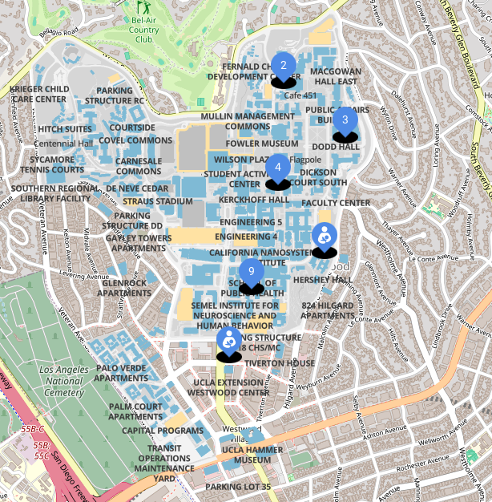

Lactation Rooms

https://chr.ucla.edu/benefits/support-nursing-mothers-at-work

[figure not shown]

Gender-Inclusive Restrooms

https://lgbtq.ucla.edu/file/1500b7f1-7c6b-4c1b-9bbe-12674dd23f67

[figure not shown]

Campus Accessibility

https://map.ucla.edu/downloads/pdf/Access_Oct_2020.pdf

## 8.2 Title IX Resources

Title IX prohibits gender discrimination, including sexual harassment, domestic and dating violence, sexual assault, and stalking. If you have experienced sexual harassment or sexual violence, there are a variety of resources to assist you.

- **CONFIDENTIAL RESOURCES**:You can receive confidential support and advocacy at the CARE Advocacy Office for Sexual and Gender-Based Violence, A233 Murphy Hall, CAREadvocate@careprogram.ucla.edu, (310) 206-2465. Counseling and Psychological Services (CAPS) also provides confidential counseling to all students and can be reached 24/7 at (310) 825-0768.
- **NON-CONFIDENTIAL RESOURCES**: You can also report sexual violence or sexual harassment directly to the University’s Title IX Coordinator, 2255 Murphy Hall, titleix@conet.ucla.edu, (310) 206-3417. Reports to law enforcement can be made to UCPD at (310) 825-1491. These offices may be required to pursue an official investigation.

*Faculty and TAs are required under the UC Policy on Sexual Violence and Sexual Harassment to inform the Title IX Coordinator should they become aware that you or any other student has experienced sexual violence or sexual harassment.*